# Analyse annotation models fitted to crowd-sourced validation dataset on populist instances among political statements on Twitter and Facebook.

Hauke Licht

2019-02-19

## Setup

```r
library(dplyr)
library(tidyr)
library(purrr)
library(ggplot2)
library(viridisLite)
theme_set(theme_minimal())

plot_path <- "./plots"
```

```r
save_plot <- partial(ggsave, path = plot_path, device = "png", width = 7, height = 7)

get_bs_sample_prevalences <- function(bs.fits, keep.categories){
  map_df(bs.fits, "est_class_prevl", .id = "boot_sample") %>%
    gather("meth", "prob", est_prob:prop_maj_winner, -category) %>%
    mutate(
      boot_sample = as.integer(boot_sample)
      , meth = case_when(
        grepl("^est_", meth) ~ "model-based classification (MC)",
        grepl("winner$", meth) ~ "majority voting (MV)",
        TRUE ~ "proportion of messages"
      )
    ) %>%
    filter(category %in% keep.categories, !grepl("^prop", meth)) %>%
    select(boot_sample, category, meth, prob) %>%
    arrange(boot_sample, category, meth) %>%
    tbl_df()
}
```

## Read in Data

```r
fits <- readRDS("./../exdata/em_fits_CF_validation_set.RData")
str(fits, 1)
```

```
## List of 4
##  $ data           :Classes 'tbl_df', 'tbl' and 'data.frame': 486 obs. of  17 variables:
##  $ anti_elitism   :List of 2
##  $ people_centrism:List of 2
##  $ exclusionary   :List of 2
```

The object `fits` is a list object.

### The original annotations data

Element `data` contains the original annotation data. This data was collected as part of the validation of the crowd-sourced measruements of populism in social media posts. Data generation involved recruiting crowd workers in *CrowdFlower* (CF), who were asked to judgement post along several measurement dimensions, three of which are of central interests here:

- *anti-elitism*: coders were asked to judge whether the post criticizes the elites (binary indicator in column `elite`)
- *people-centrisum*: coders were asked to judge whether the post praises the people and/or ordinary citizens (binary indicator in column `people`)
- *exclusionism*: coders were asked to judge whether the post explicitly excluded certain groups from ‘the people’ and/or ‘ordinary’ citizens (binary indicator in column `exclusionary`)

Each post was coded by between one to three coders.

```r
fits$data %>%
  group_by(item) %>%
  summarize(judgements = n_distinct(annotator)) %>%
  group_by(judgements) %>%
  summarize(n = n())
```

```
## # A tibble: 3 x 2
##   judgements     n
##        <int> <int>
## 1          1    13
## 2          2    43
## 3          3   129
```

### Fitted annotation models and bootstraps

The annotation data has been used to classify items into classes along the three measurement dimensions. Specifically, Dawid and Skene’s original annotation model has been fitted using the expectation-maximization algorithm ([Dawid and Skene, 1979](https://www.jstor.org/stable/2346806)). This model estimates three sets of parameters:

- *class prevalences* $\rho_k\ \forall\ k \in \mathcal{K}$, the set of outcome categories/classes (corpus-level)
- *class membership probabilities* $\pi_{ik}$ (item-level)
- *annotator sensitivities* and *specificities*

Below, this data will be used below to examine annotation quality.

## Examining annotation quality

### Anti-elitism

```r
ae_fits <- fits$anti_elitism
```

##### Prevalence

```r
ae_fits$fit$est_class_prevl
```

```
## # A tibble: 2 x 4
##   category est_prob prop_labels prop_maj_winner
##   <lgl>       <dbl>       <dbl>           <dbl>
## 1 FALSE       0.816       0.782           0.757
## 2 TRUE        0.184       0.218           0.243
```

The prevalence estimate obtained by aggregating judgements at the item-level by simple majority-vote is 24.3243243 % and is larger than the parametric prevalence estimate of anti-elite statements ( 18.3882166 %) obtained from the annotation model.

If we determine items’ classes based on estimated class membership and compute the porportion of items classified as anti-elite statements, we get

```r
ae_fits$fit$est_class_probs %>%
  select(-majority_vote) %>%
  spread(category, est_prob, sep = "_") %>%
  mutate(is_antielite = category_TRUE > category_FALSE) %>%
  summarize(prevalence = sum(is_antielite)/n())
```

```
## # A tibble: 1 x 1
##   prevalence
##        <dbl>
## 1      0.195
```

If we aggregate the 500 bootstrapped model fits, we can see that majority-voting systematically yields higher prevalence estimates as compared to parametric estimation.

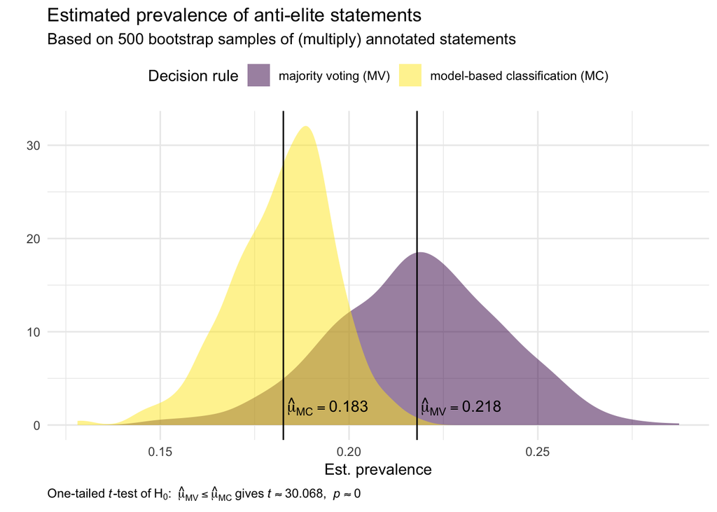

#### Classification (un)certainty

In order to quantify uncertainty in model-based classifications, I obtained the probabilistic model-based class membership point estimates from 500 bootsrapped model fits and summaize them at the item-level. This allows to compute item-level summary statistics, and to inspect the distribution of parameter estimates and its moments. Specifically, the item-level variation in class membership probabilites $\pi_{i1}$ can be visualized in a violin plot that I overlayed with point estimates (means of bootsrapped samples) and error bars (mean ± one standard-deviation). I then used colors to distinguish between different types of judgements sets and their behavior under majority voting:

- *pure negative* (*pure positive*) judgements sets are those consisting of only negative (positive) judgements, and on which majority-voting induces negative classification
- *impure negative* (*impure positive*) judgements sets are those where less than 50% but more than 0% of judgements are positive (negative), and on which majority-voting induces negative (positive) classification
- *tie* judgement sets are those with exactly 50:50 positive:negative judgements, and on which majority-voting induces no classification without specifiying a tie-breaking rule

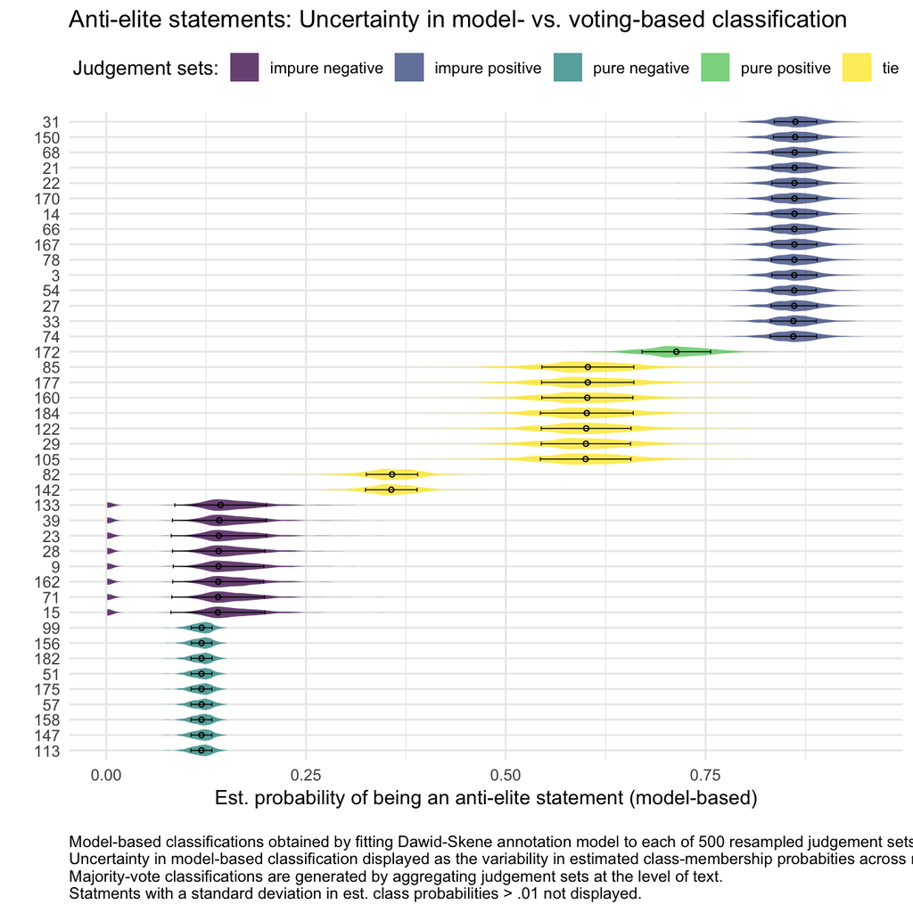

When looking only at items where class probabilities $\pi_{i1}$ vary substantively across boottrapped model fits (i.e., $\mbox{SD}(\pi_{i1}) \geq 0.01$), two things become apparent:

1. When using the original annotation data to classify items along the anti-elitism dimension by means of majority-voting, the measurement uncertainty revealed by bootsrapping annotation model fits is obscured: While items with only negative judgements are characterized by relatively low model-based classification uncertainty, this does not hold for ‘impure negative’ judgements sets. The latter applies to ‘impure positive’ items, too. Majority-voting based aggregation thus fails to convey the substantial measurement uncertainty that characterizes some items.
2. Where judgements tie, model-based classification allows to disambiguate in the overwhelming number of resampled fits: Some of the items with tied judgements are estimated to belong to the class of anti-elite statements in most bootstrapped samples, whereas for other items in this group model-based classification overwhelmingly assigns them to the non-anti-elite statement class. Thus, where simple majority-voting fails to disambiguate (and hence a random tie-breaker would need to be consulted), model-based classification is a reliable method to achieve this goal consistently.

### People-centrism

```r
pc_fits <- fits$people_centrism
```

##### Prevalence

```r
pc_fits$fit$est_class_prevl
```

```
## # A tibble: 2 x 4
##   category est_prob prop_labels prop_maj_winner
##   <lgl>       <dbl>       <dbl>           <dbl>
## 1 FALSE      0.927        0.889           0.865
## 2 TRUE       0.0733       0.111           0.135
```

The prevalence estimate obtained by aggregating judgements at the item-level by simple majority-vote is 13.5135135 % and is larger than the parametric prevalence estimate of anti-elite statements ( 7.3344678 %) obtained from the annotation model.

If we determine items’ classes based on estimated class membership and compute the porportion of items classified as anti-elite statements, we get

```r
pc_fits$fit$est_class_probs %>%
  select(-majority_vote) %>%
  spread(category, est_prob, sep = "_") %>%
  mutate(is_pc = category_TRUE > category_FALSE) %>%
  summarize(prevalence = sum(is_pc)/n())
```

```
## # A tibble: 1 x 1
##   prevalence
##        <dbl>
## 1     0.0432
```

If we aggregate the 500 bootstrapped model fits, we can see that majority-voting systematically yields higher prevalence estimates as compared to parametric estimation. A caveat of the model-based aggregation of this particular data is that the estimated prevalence of people-centrism statements is highly dependent on the judgement sets used to fit the annotation model, as indicated by the multimodality and wide spread of the density of the model-based prevalence estimates.

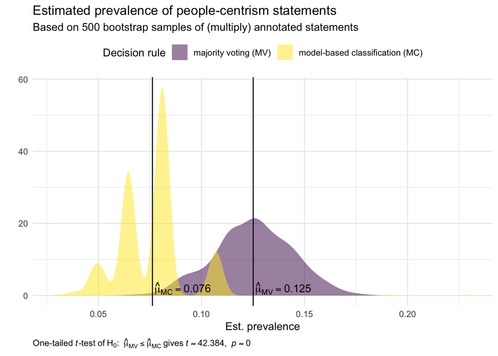

#### Classification (un)certainty

In order to quantify uncertainty in model-based classifications of people-centrism statements, I replicated the procedure described above to compute item-level summary statistics, and to inspect the distribution of parameter estimates and its moments.

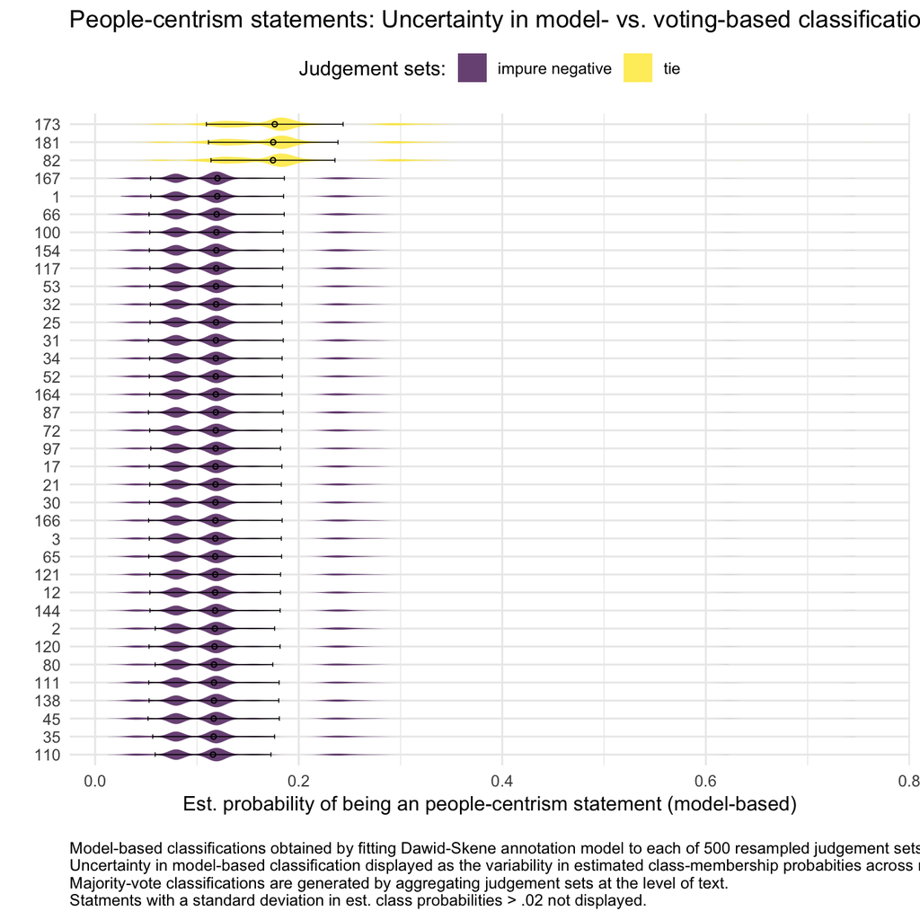

When looking only at items where class probabilities $\pi_{i1}$ vary substantively across boottrapped model fits (i.e., $\mbox{SD}(\pi_{i1}) \geq 0.02$), two things become apparent:

1. When using the original annotation data to classify items along the anti-elitism dimension by means of majority-voting, the measurement uncertainty revealed by bootsrapping annotation model fits is obscured, but classifications largely correspond.
2. Where judgements tie, model-based classification allows to disambiguate in virtually all resampled fits, and hence again: model-based classification is a reliable method to achieve this goal consistently where simple majority-voting fails to disambiguate (and hence a random tie-breaker would need to be consulted).

```r
ex_fits <- fits$exclusionary
```

##### Prevalence

```r
ex_fits$fit$est_class_prevl
```

```
## # A tibble: 2 x 4
##   category est_prob prop_labels prop_maj_winner
##   <lgl>       <dbl>       <dbl>           <dbl>
## 1 FALSE       0.869       0.854           0.859
## 2 TRUE        0.131       0.146           0.141
```

The prevalence estimate obtained by aggregating judgements at the item-level by simple majority-vote is 14.0540541 % and is close to the parametric prevalence estimate of exclusionary statements ( 13.0540767 %) obtained from the annotation model.

If we determine items’ classes based on estimated class membership and compute the porportion of items classified as exclusionary statements, we get

```r
ex_fits$fit$est_class_probs %>%
  select(-majority_vote) %>%
  spread(category, est_prob, sep = "_") %>%
  mutate(is_pc = category_TRUE > category_FALSE) %>%
  summarize(prevalence = sum(is_pc)/n())
```

```
## # A tibble: 1 x 1
##   prevalence
##        <dbl>
## 1      0.124
```

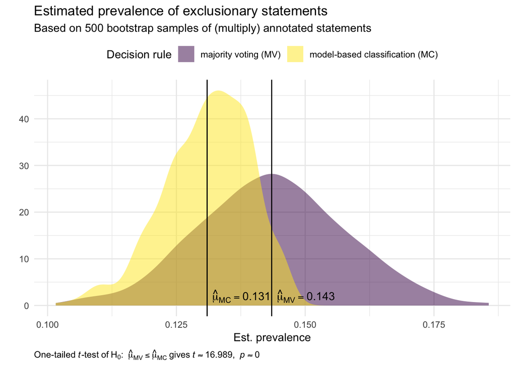

#### Classification (un)certainty

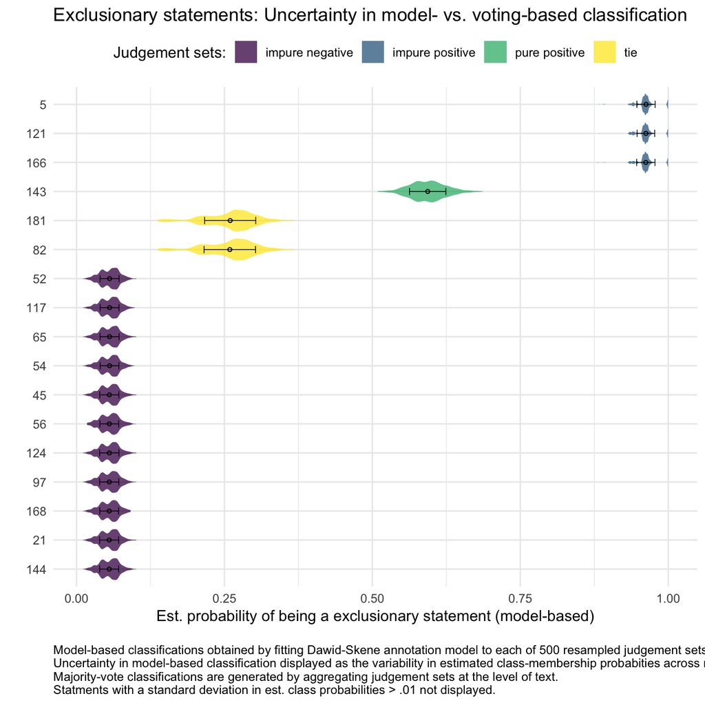

When looking only at items where class probabilities $\pi_{i1}$ vary substantively across boottrapped model fits (i.e., $\mbox{SD}(\pi_{i1}) \geq 0.01$), two things become apparent:

1. When using the original annotation data to classify items along the exclusionary dimension by means of majority-voting, the measurement uncertainty revealed by bootsrapping annotation model fits is generally obscured. But the number of items where measurement uncertainty come close the .5 classification cutoff is substantially negligible.
2. Where judgements tie, model-based classification allows to disambiguate in all resampled fits.